# Slow R

Rick Gilmore

2019-08-21 04:50:34

# Preliminaries

> We’re not slow; we’re not fast. We’re half-fast.

(Joke my Dad didn’t think I got as a kid.)

This tutorial is intended as a very slow introduction to using R. If we’re going too slow for you, it’s ok to work ahead or help a neighbor who’s not so speedy. But if we’re going too fast, please say so! We think that by going slow at the start, it will be easier to speed up later.

## Talking to the computer

We talk about programming a computer or coding, but most of the time we’re having a conversation. We say something, and the computer responds. We say something else, and the computer responds. And so on.

In this section, we’ll learn how to talk to the computer in a language it understands. That language is R.

## Why learn R?

It’s fun. It’s free. You can amaze your friends and dazzle your rivals. It’s powerful, especially for manipulating, plotting, and analyzing data.

**It will make you a more productive researcher.** That’s the bottom line.

> What if I want to learn another programming language?

Awesome! Good for you. Learn a bunch of languages. They’re a bit like human languages: It’s easier or more poetic to say some things in some languages than it is in others. But make sure you develop some mastery over one computer language before learning another one. Other useful languages for behavioral scientists to learn include the following: Python, Matlab, *nix shell programming, HTML/CSS/JavaScript, SQL, C/C++, and Java, for starters.

Just for fun, here is some data about the languages Bootcamp registrants reported knowing something about:

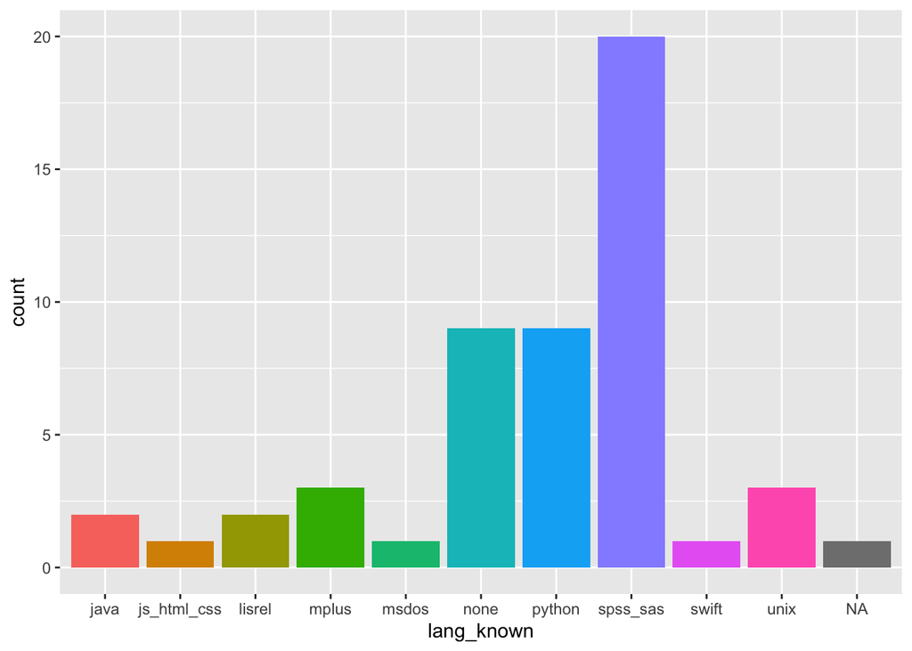

```r
survey <- readr::read_csv(params$survey_fn)

survey %>% ggplot2::ggplot(.) + ggplot2::aes(x = lang_known, fill = lang_known) +
    ggplot2::geom_bar() + ggplot2::theme(legend.position = "none")
```

## Why RStudio?

[RStudio](http://rstudio.com) is an integrated development environment (IDE) for R. RStudio brings together a number of useful tools for talking to the computer in R. You don’t have to use RStudio to use R, but you should use it for this bootcamp, and we *strongly* recommend using it in the future. It’s suitable for beginners and experts.

# RStudio and the Console

## RStudio

I’m going to login to a version of RStudio that Penn State hosts so that Penn Staters can use RStudio from a web browser. Detailed instructions can be found at http://psu-psychology.github.io/r-bootcamp-2019/before-the-bootcamp.html.

In brief, I enter https://lxclusterapps.tlt.psu.edu:8787 in my browser, enter my PSU Access ID (rog1) and password, then click on the the `Sign In` button with my mouse or press return on my keyboard. Then I see an RStudio window that looks very much like this one:

[figure not shown]

Let’s everyone log-on to RStudio Server Pro.

This is the default view. It has several different “windows” or panels. They each provide us with helpful information. You can rearrange them or customize RStudio to your heart’s content. But do that later. For now, let’s concentrate on the panel on the left side called the `Console`.

## Console

The console is where you do most of your talking to R. Notice that there is some text, and then a greater-than sign (`>`) sign. Let’s read the text.

Besides the version of R and some other details, it tells us how to start a conversation with R. It says `Type 'license()' or 'licence()' for distribution details.` Let’s try that.

Type ‘license()’ right after the greater-than `>` sign. Press the `return` or `enter` key on your keyboard to tell R you’ve finished saying something.

```r
"license()"
```

```
## [1] "license()"
```

Well, that wasn’t very interesting. The computer responded by repeating what we’d typed, changing the single quotation marks for double quotation marks, but that’s about it.

> Painful lesson #1: Computers are super-literal. They are anally literal. More anally literal than any human being you’ve ever had to deal with. You’re not going to change them. Just deal.

Try typing `license()` *without* the single quotation marks (and hit return/enter).

```r
license()
```

```
##
## This software is distributed under the terms of the GNU General
## Public License, either Version 2, June 1991 or Version 3, June 2007.
## The terms of version 2 of the license are in a file called COPYING
## which you should have received with
## this software and which can be displayed by RShowDoc("COPYING").
## Version 3 of the license can be displayed by RShowDoc("GPL-3").
##
## Copies of both versions 2 and 3 of the license can be found
## at https://www.R-project.org/Licenses/.
##
## A small number of files (the API header files listed in
## R_DOC_DIR/COPYRIGHTS) are distributed under the
## LESSER GNU GENERAL PUBLIC LICENSE, version 2.1 or later.
## This can be displayed by RShowDoc("LGPL-2.1"),
## or obtained at the URI given.
## Version 3 of the license can be displayed by RShowDoc("LGPL-3").
##
## 'Share and Enjoy.'
```

Much better! So, this was our first ‘conversation’ with the computer. We said something in R, and the computer responded.

Why did typing `license()` work but typing `'license()'` not work? The quotation marks. Typing `license()` without them gave R a command; surrounding the same characters with single quotation marks told R that all of those characters were a single unit a string of characters (called a *string*), but definitely *not* a command. As I said, computers are *very* literal. Many of the errors and frustrations you will encounter in your R journey will come down to your not telling the computer what to do in EXACTLY the way it needs to be told.

### Parts of the console

The console refers to the whole window or panel. Notice that as we type text or R does, that text scrolls up so we can see the recent history of our conversation. You can scroll (with your mouse or arrow keys) up and down in the console.

The greater-than (`>`) character is called the ‘prompt’, and the vertical line or pipe character (`|`) is called the ‘cursor’. You already knew about the cursor from your experiences in other computer programs. It’s where characters we type will be entered. The prompt is just a character to ‘prompt’ or remind us that R is waiting for us to say something.

### Interacting with R via the console

Typing in the console is just one way to talk to the computer. It’s *interactive*, meaning we type, it responds. Or really, we command, it responds (if it can). This way of talking to computers is very old school. It goes back to the 60s. It might seems less powerful than say clicking buttons or menu items or talking to Siri or Alexa. But just wait and see. The console is our window into the computer’s brain.

What’s happening under the hood here? When the console displays the prompt it means that R is waiting for you to do something. That something is to type something and hit the `return` key. When you hit `return`, R tries to ‘understand’ what you typed and do something sensible in response.

> Complex programs are just long sequences of commands entered into something like the computer’s hidden internal console and the computer’s responses to those commands.

# Talking to R

So, what can you say to R? You can give R commands and ask it simple questions.

When you type things that end with parentheses like `license()`, that commands R to do something, in this case, to ‘print the license information’. Why doesn’t R require you to say `print_license()`? To save typing.

Here’s another command: `sum(1, 4, 7)`

```r
sum(1, 4, 7)
```

```
## [1] 12
```

This command says ‘calculate and print the sum of the numbers 1, 4, and 7’. R responds with the answer: 12. Notice that there are two parts to the command: the ‘what to do’ part (`sum`) and the ‘what to do it with or on’ part inside the parentheses, here `(1,4,7)`. We’ll return to this later, but many, many things we want to do or say in life (and R life) have two parts, the ‘verb’ or action we want to do and the ‘noun’ or objects/people we want to involve in that action. The parentheses tell R which is which when it reads the command from the console.

Imagine if human languages were like this:

```
feed(me, 'grapes')
fetch(that_bone)
```

Not surprisingly, there can be many similarities in the way computer languages are structured and human languages.

## Files and folders/directories

Before we talk about other things you can say to the computer, let’s talk about where and how computers store data and instructions or commands.

Computers store data & instructions (programs, scripts etc.) in two types of memory:

- **Long-term** (between work sessions) in *files*.
- **Short-term** (during your work session) in *volatile memory*. It’s volatile because these items will *not* be saved across sessions unless you do something to save them to a file.

We’ll talk about files first.

Files are organised in directories or folders. Directories or folders are a tree-like structure for organizing files. Like trees, there can be multiple branches. Directories/folders often have a hierarchy of branches. The set of directories to a file is called the **path**.

I can list the files in a directory or folder using the `list.files()` command or list the directories using the `list.dirs()` command.

```r
# List the files in my current directory
list.files()
```

```
##  [1] "bootcamp-day-1-intro_cache"
##  [2] "bootcamp-day-1-intro_files"
##  [3] "bootcamp-day-1-intro.html"
##  [4] "bootcamp-day-1-intro.Rmd"
##  [5] "bootcamp-survey.html"
##  [6] "bootcamp-survey.Rmd"
##  [7] "codebook_survey_cache"
##  [8] "codebook_survey_files"
##  [9] "codebook_survey.pdf"
## [10] "codebook_survey.Rmd"
## [11] "css"
## [12] "data_analyses_cache"
## [13] "data_analyses_files"
## [14] "data_analyses_practice.html"
## [15] "data_analyses_practice.Rmd"
## [16] "data_analyses_supp.html"
## [17] "data_analyses_supp.Rmd"
## [18] "data_analyses.html"
## [19] "data_analyses.Rmd"
## [20] "r-eproducible-science_cache"
## [21] "r-eproducible-science_files"
## [22] "r-eproducible-science.html"
## [23] "r-eproducible-science.Rmd"
## [24] "RBootcamp_MLMInteractions_2019_0820_Final2.html"
## [25] "RBootcamp_MLMInteractions_2019_0820_Final2.Rmd"
## [26] "slow-r_cache"
## [27] "slow-r_files"
## [28] "slow-r.html"
## [29] "slow-r.Rmd"
```

Notice that files have *names* (e.g., `slow-r`) and *extensions* that start with a period (e.g., `.Rmd`). The extension is a way for the computer to communicate with itself and others what type of file is being stored. You’re probably familiar with files that have one of these extensions: .docx, .xlsx, .html, and .pdf. Some computer systems hide the file extention part, but I most power users like to show it.

In addition to knowing ‘what’ files are already stored, we often want to know ‘where’ they are stored. In computer terms, this means that we want to know where we are working in this hierarchy of directories or folders. The ‘tell me (get) the working directory’ or `getwd()` command shows us this information.

```r
# Get and print the current working directory
getwd()
```

```
## [1] "/Users/rick/github/psu-psychology/r-bootcamp-2019/talks"
```

I can change my working directory, but we’re going to suggest you don’t do that. There are much easier and reproducible ways to do things in R right from the comfort of your working directory. In any event, as you continue your jouRney with R, you’ll want to practice a form of ‘situational awareness’: Where am I now (in my computer’s file system). Don’t worry, this will eventually become second nature to you.

In the next section, we’ll see how we can store information in R’s short-term memory.